# Projet

Louis Henri Franc

19 novembre 2016

```r
# Pour obtenir les mêmes résultats
library("ISLR")
library("pastecs")
library("leaps")
library("glmnet")
library("pls")
library("class")
library("MASS")
library(boot)
library(tree)
library(randomForest)
set.seed(123)
```

## Introduction au données

Pour le devoir j’ai décidé de travailler sur l’ensemble de donnée **House Sales In King County**. Il est disponible sur cette page (https://www.kaggle.com/harlfoxem/housesalesprediction/kernels). Le but de ce projet sera de **prédire le prix d’une maison en fonction de ces caractéristiques tel que sa superficie, le nombre d’étages, le nombre de chambres.**

```r
# Importer les données
data <- read.csv("kc_house_data.csv")
```

Regardons ensemble, quelles sont les données disponibles dans cet ensemble de donnée

```r
# Afficher quelques lignes
head(data)
```

```
##           id            date   price bedrooms bathrooms sqft_living
## 1 7129300520 20141013T000000  221900        3      1.00        1180
## 2 6414100192 20141209T000000  538000        3      2.25        2570
## 3 5631500400 20150225T000000  180000        2      1.00         770
## 4 2487200875 20141209T000000  604000        4      3.00        1960
## 5 1954400510 20150218T000000  510000        3      2.00        1680
## 6 7237550310 20140512T000000 1225000        4      4.50        5420
##   sqft_lot floors waterfront view condition grade sqft_above sqft_basement
## 1     5650      1          0    0         3     7       1180             0
## 2     7242      2          0    0         3     7       2170           400
## 3    10000      1          0    0         3     6        770             0
## 4     5000      1          0    0         5     7       1050           910
## 5     8080      1          0    0         3     8       1680             0
## 6   101930      1          0    0         3    11       3890          1530
##   yr_built yr_renovated zipcode     lat     long sqft_living15 sqft_lot15
## 1     1955            0   98178 47.5112 -122.257          1340       5650
## 2     1951         1991   98125 47.7210 -122.319          1690       7639
## 3     1933            0   98028 47.7379 -122.233          2720       8062
## 4     1965            0   98136 47.5208 -122.393          1360       5000
## 5     1987            0   98074 47.6168 -122.045          1800       7503
## 6     2001            0   98053 47.6561 -122.005          4760     101930
```

```r
# Nombre d'examples
nrow(data)
```

```
## [1] 21613
```

```r
# Nombre de features
ncol(data)
```

```
## [1] 21
```

Cette base de donnée est constitué d’un très grand nombre d’examples, ce qui nous permettra d’entrainer plusieurs modèles de prédiction, et de séparer nos données en un ensemble d’entrainement et un ensemble de validation.

## Nettoyage des données

#### Sélection des prédicateurs utilisées

Parmi les données, certaines ne nous permettront pas de prédire le prix des maisons, les supprimer est légitime, il s’agit de l’id, la date, le zipcode, la lattitude, et la longitude. Cela me semblait être des potentiels sources de confusion pour l’entrainement des modèles.

```r
data = data[,-c(1:2, 17:19)]
```

#### Suppression des données abérantes

La suppression des données abérrantes autant pour les prédicateurs, que pour les variables explicatives permet, en général, d’améliorer la qualité des modèles. Cela permet par exemple de réduire la variance. Comme nous avons beaucoup d’examples, les supprimer est possible. Nous allons seulement supprimer les outliers des prédicateurs de surface, mais aussi de la variable explicative *prix*. En effet, dans notre base de donnée se trouvent certainement des maisons très cheres, ou très bas prix, et prédire leur prix sera difficile pour tout modèle. Si le modèle est suffisament flexible, il pourra peut être prédire le prix de ces exemples, mais le modèle overfittera certainement.

```r
remove_outliers <- function(x, na.rm = TRUE, ...) {
  qnt <- quantile(x, probs=c(.25, .75), na.rm = na.rm, ...)
  H <- 4 * IQR(x, na.rm = na.rm)
  y =
    y = c(which(x < (qnt[1] - H)),which(x > (qnt[2] + H)))
  y
}
num = 0
for(name  in names(data)){
  if(grepl("sqft", name) || name == "price"){
    outliers = remove_outliers(data[,name])
    num = num + length(outliers)
    data = data[-outliers,]
  }
}
# Nombre de données supprimées
print(num)
```

```
## [1] 2030
```

```r
# Nombre de données restantes
print(nrow(data))
```

```
## [1] 19583
```

Supprimer les données abérrantes va, évidemment, réduire le RSS, MSE calculés de nos données. Mais cela permettra sans doute de converger vers une solution qui généralisera mieux.

#### Décorrélation des prédicateurs

Afin d’éviter d’avoir des prédicateurs trop corrélés, nous allons supprimer une des deux variables des paires de prédicateurs qui ont une corrélation supérieur à 0.75. Les méthodes de sélection de sous modèles ont des performances accrues lorsque les variables explicatives ne sont pas trop corrélés.

```r
tmp = cor(data)
tmp[lower.tri(tmp)] = 0
diag(tmp) =  0
data1 = data[, !apply(tmp, 2, function(x) any(x > 0.75))]
setdiff(names(data), names(data1))
```

```
## [1] "sqft_above"    "sqft_living15" "sqft_lot15"
```

```r
data = data1
```

Trois variables ont été supprimés du modèle. Il s’agit de sqft_above, sqftliving15, sqft_lot15. Elles sont en effet très corrélés avec la variable sqft_living…

#### Transformation des données non numériques

```r
as.dummy_variable = function (data){
  data$floor = factor(data$floor)
  data$view = factor(data$view)
  data$condition = factor(data$condition)
  data$grade = factor(data$grade)
  return(data)
}
```

#### Séparation des ensembles d’entrainements et de tests

Les données vont être séparés en deux groupes qui serviront pour l’entrainement de nos modèles. Pour cela, nous allons utiliser la méthode *sample*

```r
smp_size = floor(0.7 * nrow(data))
train_ind = sample(seq_len(nrow(data)), size = smp_size)
train = data[train_ind,]
test = data[-train_ind,]
```

## Quelques statistiques sur nos données

```r
summary(data)
```

```
##      price            bedrooms        bathrooms      sqft_living
##  Min.   :  78000   Min.   : 0.000   Min.   :0.000   Min.   : 290
##  1st Qu.: 315000   1st Qu.: 3.000   1st Qu.:1.500   1st Qu.:1400
##  Median : 439000   Median : 3.000   Median :2.250   Median :1850
##  Mean   : 506314   Mean   : 3.348   Mean   :2.071   Mean   :1988
##  3rd Qu.: 620000   3rd Qu.: 4.000   3rd Qu.:2.500   3rd Qu.:2440
##  Max.   :1928000   Max.   :33.000   Max.   :7.500   Max.   :6630
##     sqft_lot         floors        waterfront            view
##  Min.   :  520   Min.   :1.000   Min.   :0.000000   Min.   :0.0000
##  1st Qu.: 4976   1st Qu.:1.000   1st Qu.:0.000000   1st Qu.:0.0000
##  Median : 7245   Median :1.000   Median :0.000000   Median :0.0000
##  Mean   : 7824   Mean   :1.487   Mean   :0.004136   Mean   :0.2046
##  3rd Qu.: 9604   3rd Qu.:2.000   3rd Qu.:0.000000   3rd Qu.:0.0000
##  Max.   :32481   Max.   :3.500   Max.   :1.000000   Max.   :4.0000
##    condition         grade        sqft_basement       yr_built
##  Min.   :1.000   Min.   : 1.000   Min.   :   0.0   Min.   :1900
##  1st Qu.:3.000   1st Qu.: 7.000   1st Qu.:   0.0   1st Qu.:1950
##  Median :3.000   Median : 7.000   Median :   0.0   Median :1972
##  Mean   :3.411   Mean   : 7.565   Mean   : 282.7   Mean   :1970
##  3rd Qu.:4.000   3rd Qu.: 8.000   3rd Qu.: 550.0   3rd Qu.:1997
##  Max.   :5.000   Max.   :12.000   Max.   :2610.0   Max.   :2015
##   yr_renovated
##  Min.   :   0.00
##  1st Qu.:   0.00
##  Median :   0.00
##  Mean   :  79.92
##  3rd Qu.:   0.00
##  Max.   :2015.00
```

## Simple regression à une variable explicative

Nous allons tout d’abord effectuer des régressions simple à un prédicateur entre le prix et les variables les plus corrélées :

```r
cor_matrix = cor(data)
cor_matrix[,"price"]
```

```
##         price      bedrooms     bathrooms   sqft_living      sqft_lot
##    1.00000000    0.30598400    0.48186574    0.66031611    0.11239660
##        floors    waterfront          view     condition         grade
##    0.26696595    0.14587787    0.36062051    0.05249493    0.66324669
## sqft_basement      yr_built  yr_renovated
##    0.30394940    0.02994293    0.13446924
```

La variable numérique explicative la plus corrélée est *sqft-living*.

#### **Prix en fonction de la surface habitée**

```r
lm.fit =lm(price ~ sqft_living, data=train)
summary(lm.fit)
```

```
##
## Call:
## lm(formula = price ~ sqft_living, data = train)
##
## Residuals:
##     Min      1Q  Median      3Q     Max
## -752305 -138675  -21914  101686 1243428
##
## Coefficients:
##              Estimate Std. Error t value Pr(>|t|)
## (Intercept) 53371.070   4714.600   11.32   <2e-16 ***
## sqft_living   227.143      2.197  103.37   <2e-16 ***
## ---
## Signif. codes:  0 '***' 0.001 '**' 0.01 '*' 0.05 '.' 0.1 ' ' 1
##
## Residual standard error: 206900 on 13706 degrees of freedom
## Multiple R-squared:  0.4381, Adjusted R-squared:  0.438
## F-statistic: 1.069e+04 on 1 and 13706 DF,  p-value: < 2.2e-16
```

```r
lm.pred = predict(lm.fit, test)
lm.rmse = sqrt(mean((lm.pred - test$price) ^2) )
# Racine carée du MSE du modèle
lm.rmse
```

```
## [1] 209455.5
```

D’après le R^2 ajusté, la variance dans le prix de la maison s’explique en moitié uniquement par la donnée *sqft-living*. Le RMSE est cependant élevé, ce qui indique que le simple modèle linéaire est probablement incomplet, ou trop simple. Nous allons à présent afficher le nuage de point.

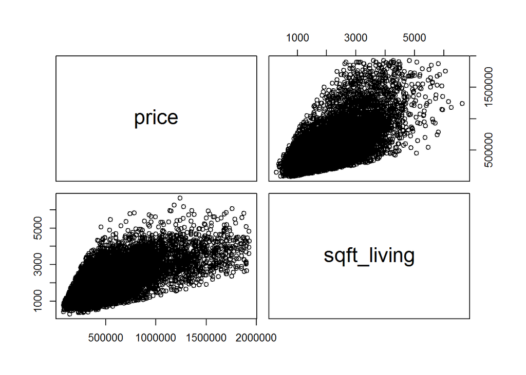

```r
pairs(data[, c(1,4)])
```

En regardant la courbe, il semblerait que la variabilité du prix augmente avec la surface habituée. Nous pouvons essayer de multiplier la surface par elle même et la considérer comme une nouvelle variable explicative.

```r
lm.fit =lm(price ~  I(sqft_living ^ (2)), data=train)
summary(lm.fit)
```

```
##
## Call:
## lm(formula = price ~ I(sqft_living^(2)), data = train)
##
## Residuals:
##      Min       1Q   Median       3Q      Max
## -1100069  -137821   -26246    98835  1280545
##
## Coefficients:
##                     Estimate Std. Error t value Pr(>|t|)
## (Intercept)        2.906e+05  2.708e+03   107.3   <2e-16 ***
## I(sqft_living^(2)) 4.663e-02  4.470e-04   104.3   <2e-16 ***
## ---
## Signif. codes:  0 '***' 0.001 '**' 0.01 '*' 0.05 '.' 0.1 ' ' 1
##
## Residual standard error: 206100 on 13706 degrees of freedom
## Multiple R-squared:  0.4425, Adjusted R-squared:  0.4424
## F-statistic: 1.088e+04 on 1 and 13706 DF,  p-value: < 2.2e-16
```

```r
lm.pred = predict(lm.fit, test)
sqrt(mean((lm.pred - test$price) ^2) )
```

```
## [1] 208662.5
```

Après essai de plusieurs modifications non linéaires de sqft_living (sqrt, log, ^2, ^3), aucune ne semble amélioré la régression.

## Approche par la régression LASSO

L’avantage de la régression LASSO est qu’elle permet de sélectionner parmi les variables explicatives celles qui expliquent le mieux la variable dépendante. Si le coefficient $\beta$ de la variable explicative tend vers zéro, alors la variable ne peut influencer la prédiction de la variable dépendante. Suivant les résultats de l’algorithme, nous allons restreindre, ou non, notre modèle encore plus.

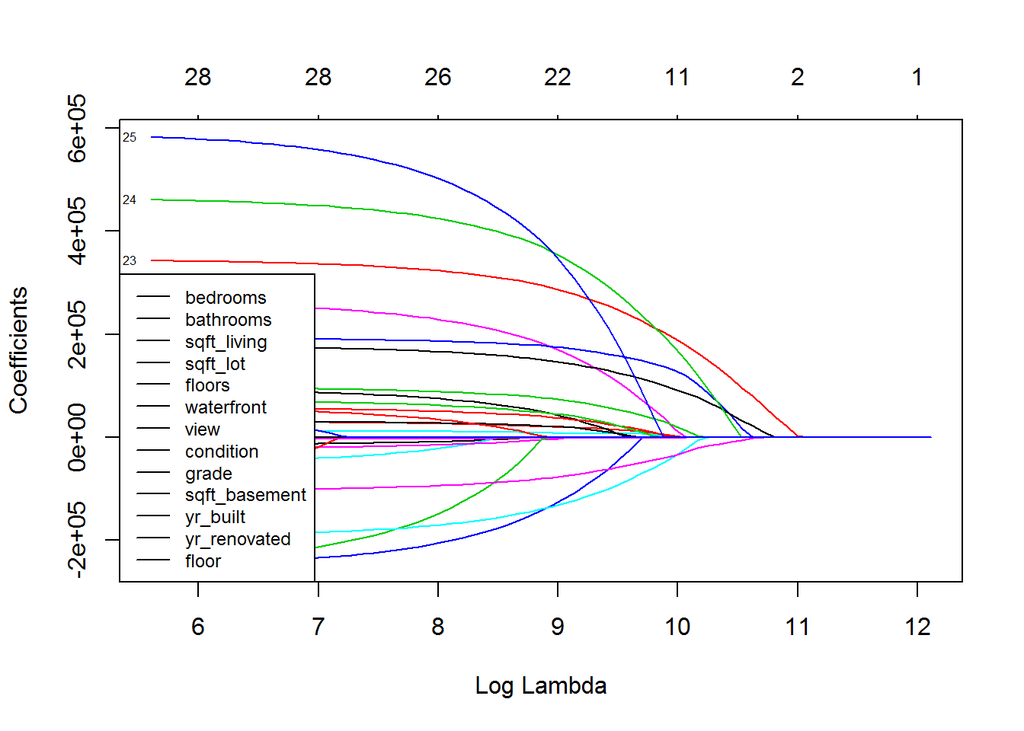

```r
# Transformer les données non numériques en dummy variable
data = as.dummy_variable(data)
train = data[train_ind,]
test = data[-train_ind,]

# LASSO REGRESSION MODEL
x = model.matrix(price ~., data=train)
y = train[,1]
fit.lasso = glmnet(x, y, alpha = 1)
plot(fit.lasso, xvar="lambda", label=T)
legend("bottomleft", names(train[-1]), lty=1, cex=.75)
```

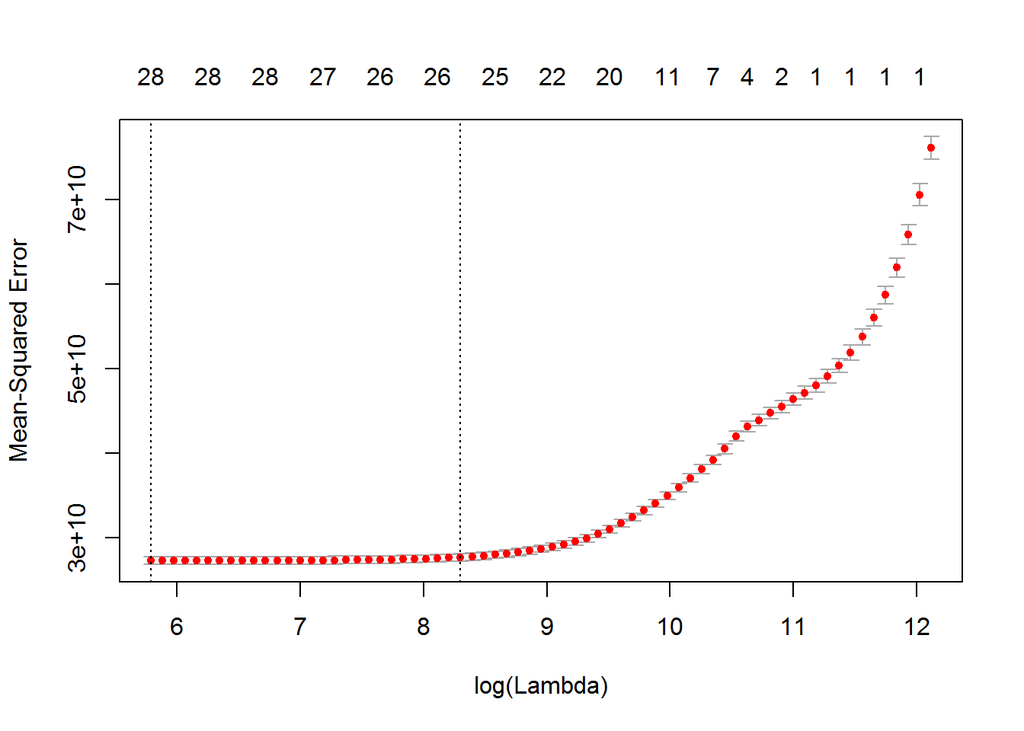

```r
# Valeur optimal de LAMBDA en utilisant la méthode de CROSS VALIDATION
cv.lasso = cv.glmnet(x,y, alpha=1)
plot(cv.lasso)
```

```r
lambda.min = cv.lasso$lambda.min
print(lambda.min)
```

```
## [1] 326.739
```

```r
fit.lasso = glmnet(x, y,alpha = 1, lambda = lambda.min)
fit.pred = predict(fit.lasso, model.matrix(price~.,data=test))
print(paste("RMSE : ", sqrt(mean((fit.pred - test$price) ^ 2))))
```

```
## [1] "RMSE :  164778.582907721"
```

```r
# Coefficient des variables explicatives
coef.lasso = coef(cv.lasso)
coef.lasso
```

```
## 34 x 1 sparse Matrix of class "dgCMatrix"
##                           1
## (Intercept)    5.357123e+06
## (Intercept)    .
## bedrooms      -6.316303e+03
## bathrooms      2.477882e+04
## sqft_living    1.223387e+02
## sqft_lot      -3.432196e+00
## floors         1.047572e+04
## waterfront     2.170895e+05
## view1          6.868382e+04
## view2          4.775761e+04
## view3          8.550401e+04
## view4          1.843535e+05
## condition2    -1.091966e+04
## condition3    -1.250071e+04
## condition4     .
## condition5     2.613684e+04
## grade3         .
## grade4        -1.125385e+05
## grade5        -1.898672e+05
## grade6        -1.627385e+05
## grade7        -9.070637e+04
## grade8         .
## grade9         1.621404e+05
## grade10        3.167587e+05
## grade11        4.110048e+05
## grade12        4.716455e+05
## sqft_basement  7.570816e+00
## yr_built      -2.588052e+03
## yr_renovated   1.174276e+01
## floor1.5       .
## floor2         .
## floor2.5       2.646550e+04
## floor3         5.832920e+04
## floor3.5       .
```

Pour un lambda optimal obtenue par la méthode de *cross validation* (326.739), les coefficients de *sqft_lot*, *sqft_basement* et *yr.renovated* est tout proche de zéro, nous allons donc les supprimer de la régression.

```r
data = data[, -c(5, 11, 13)]
train = data[train_ind,]
test = data[-train_ind,]
```

## Approche par meilleur sous ensembles.

Nous allons utiliser la méthode de *forward selection* afin de trouver le meilleur modèle de régression, mais aussi le nombre de variables explicatives qui expliquent le modèle. Le nombre maximal de variable explicative à considérer sera 10.

```r
# FORWARD STEPWISE SELECTION
regfw.subset = regsubsets(price ~ ., train, nbest = 1, nvmax = ncol(data)-1, method= "forward")
```

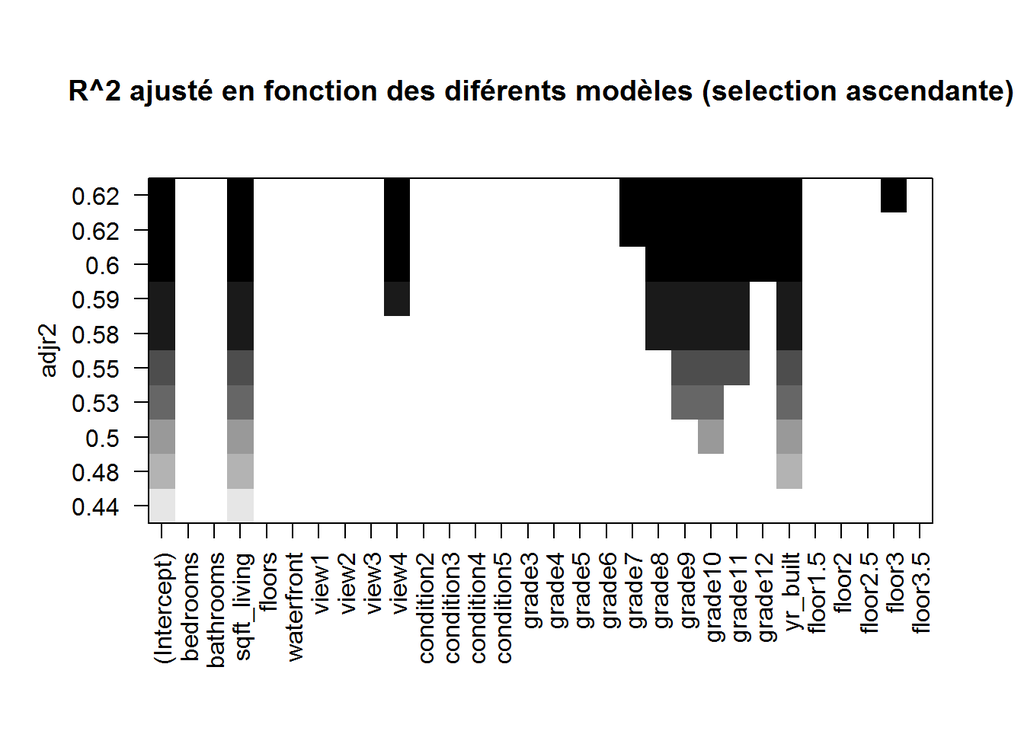

```r
regfwd.summary = summary(regfw.subset)
plot(regfw.subset, scale = "adjr2", main = "R^2 ajusté en fonction des diférents modèles (selection ascendante)")
```

```r
# BACKWARD STEPWISE SELECTION
regfw.subset = regsubsets(price ~ ., train, nbest = 1, nvmax = ncol(data)-1, method= "backward")
```

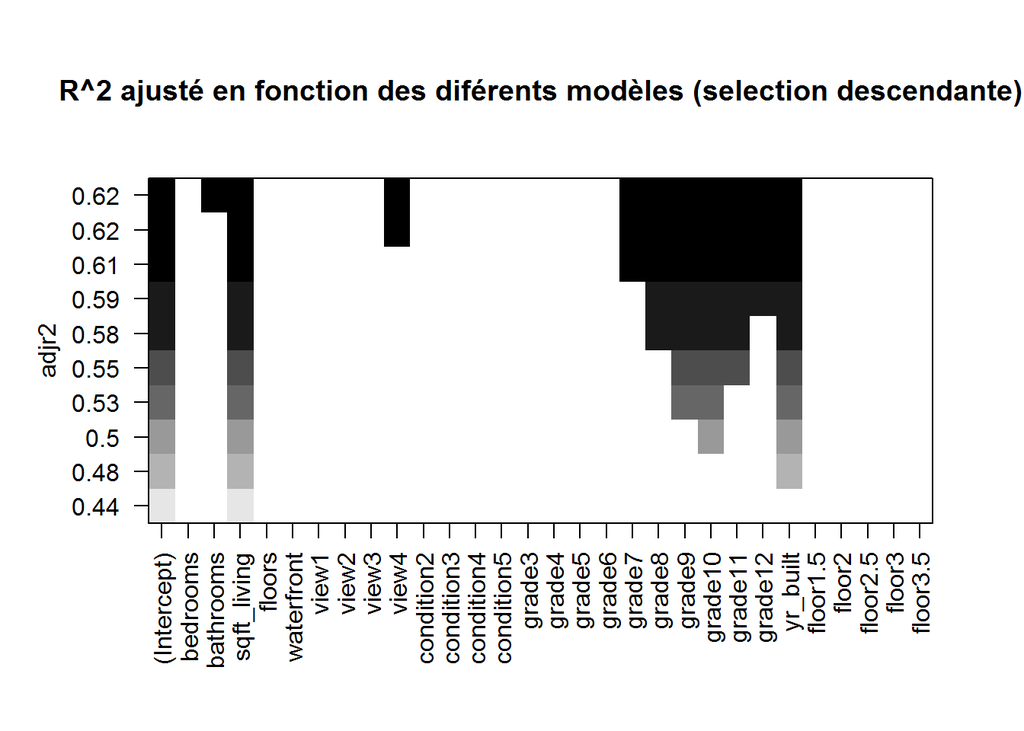

```r
regfwd.summary = summary(regfw.subset)
plot(regfw.subset, scale = "adjr2", main = "R^2 ajusté en fonction des diférents modèles (selection descendante)")
```

Nous allons ensuite sélectionner le meilleur des 10 modèles par la méthode de *cross validation*.

```r
# CROSS VALIDATION
folds = sample(rep(1:10, length = nrow(train)))
cv.errors = matrix(NA, 10, ncol(data) - 1)

prediction.regsubsets = function(object, newdata, id, ...){
  form = as.formula(object$call[[2]]) #extract object model formula for y ~ x
  mat = model.matrix(form, newdata) #set prediction matrix
  coefi = coef(object, id = id) #obtain matrix of coefficients
  mat[, names(coefi)] %*% coefi #calculate predictions matrix
}

for(k in 1:10){
  best.fit = regsubsets(price ~ .  , data = train[folds != k, ], nvmax = ncol(data)-1,
                        method = "forward")
  for(i in 1:(ncol(data)-1)){
    pred = prediction.regsubsets(best.fit, train[folds == k, ], id = i)

    cv.errors[k, i] = mean((train$price[folds == k] - pred) ^ 2)
  }
}
```

```
## Reordering variables and trying again:
```

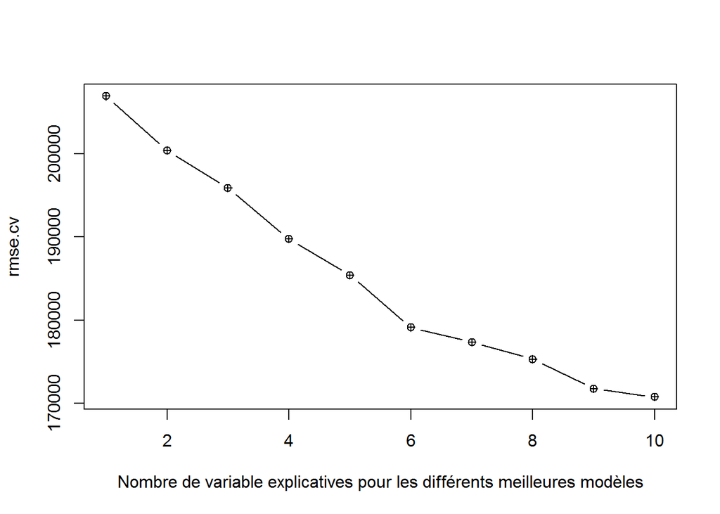

```r
rmse.cv = sqrt(apply(cv.errors, 2, mean))
plot(rmse.cv, pch = ncol(data)-1, type = "b",xlab = "Nombre de variable explicatives pour les différents meilleures modèles")
```

```r
# MEILLEUR Modèle sur l'ensemble d'entrainements
which.min(rmse.cv)
```

```
## [1] 10
```

Le meilleur validé est donc le modèle 10, que nous allons utiliser sur nos données de test.

```r
x.test = model.matrix(price ~., data = test)

# Calculer le MSE pour tous les modèles (et voir si le modèle choisi minimise le MSE des données de test)
coefi = coef(regfw.subset, id = 10)
pred = x.test[ , names(coefi)] %*% coefi
paste("Modele 10, RMSE = ",sqrt(mean((test$price - pred) ^ 2)))
```

```
## [1] "Modele 10, RMSE =  171457.71092754"
```

## Approche composantes principales

L’approche des composantes principales est une autre techniques statistiques permettant de trouver les variables $X_i$ de la régression qui explique le maximum de variance de l’*output*.

```r
pcr.fit = pcr(price ~., data=data, scale=T, validation="CV", ncomp=27)
summary(pcr.fit)
```

```
## Data:    X dimension: 19583 29
##  Y dimension: 19583 1
## Fit method: svdpc
## Number of components considered: 27
##
## VALIDATION: RMSEP
## Cross-validated using 10 random segments.
##        (Intercept)  1 comps  2 comps  3 comps  4 comps  5 comps  6 comps
## CV          276527   243636   205658   201720   201623   197521   196540
## adjCV       276527   243635   205645   201699   201606   197500   196523
##        7 comps  8 comps  9 comps  10 comps  11 comps  12 comps  13 comps
## CV      195857   192119   191811    191778    191749    191070    190893
## adjCV   195858   191866   191772    191784    191790    191020    190961
##        14 comps  15 comps  16 comps  17 comps  18 comps  19 comps
## CV       190672    190386    190048    189708    189251    188639
## adjCV    190682    190315    189983    189860    189237    188629
##        20 comps  21 comps  22 comps  23 comps  24 comps  25 comps
## CV       188502    188433    178661    178591    167097    166197
## adjCV    188483    188414    178635    178578    167075    166177
##        26 comps  27 comps
## CV       166213    166228
## adjCV    166193    166206
##
## TRAINING: % variance explained
##        1 comps  2 comps  3 comps  4 comps  5 comps  6 comps  7 comps
## X        15.22    22.23    27.71    32.84    37.47    41.81    45.81
## price    22.39    44.72    46.83    46.91    49.05    49.56    49.91
##        8 comps  9 comps  10 comps  11 comps  12 comps  13 comps  14 comps
## X        49.67    53.47     57.11     60.69     64.23     67.73     71.20
## price    51.97    51.97     51.97     51.99     52.44     52.44     52.56
##        15 comps  16 comps  17 comps  18 comps  19 comps  20 comps
## X         74.64     78.05     81.45     84.83     88.03     91.07
## price     52.77     52.95     52.96     53.31     53.64     53.73
##        21 comps  22 comps  23 comps  24 comps  25 comps  26 comps
## X         93.73     95.61     97.13     98.40     99.41     99.99
## price     53.77     58.42     58.45     63.64     64.03     64.04
##        27 comps
## X        100.00
## price     64.04
```

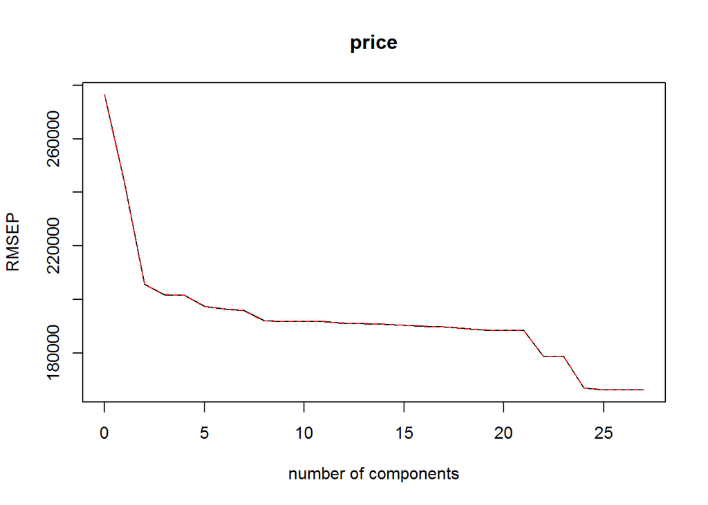

```r
validationplot(pcr.fit, val.type = "RMSEP")
```

```r
pcr.fit = pcr(price ~ ., data=train, scale=T, validation="CV", ncomp= 24)
pcr.pred = predict(pcr.fit, test, ncomp = 24)
sqrt(mean((pcr.pred - test$price) ^2))
```

```
## [1] 167071.6
```

#### Arbre de regression

Pour finir, nous allons utiliser la technique des arbres de régression, en effectuant la régression de la variable prix en utilisant les autres variables disponibles. Nous allons démarrer avec un simple arbre.

```r
tree.fit = tree(price~., data=train)
summary(tree.fit)
```

```
##
## Regression tree:
## tree(formula = price ~ ., data = train)
## Variables actually used in tree construction:
## [1] "grade"       "sqft_living" "yr_built"
## Number of terminal nodes:  8
## Residual mean deviance:  3.515e+10 = 4.815e+14 / 13700
## Distribution of residuals:
##    Min. 1st Qu.  Median    Mean 3rd Qu.    Max.
## -758400 -122300  -28350       0   93680 1358000
```

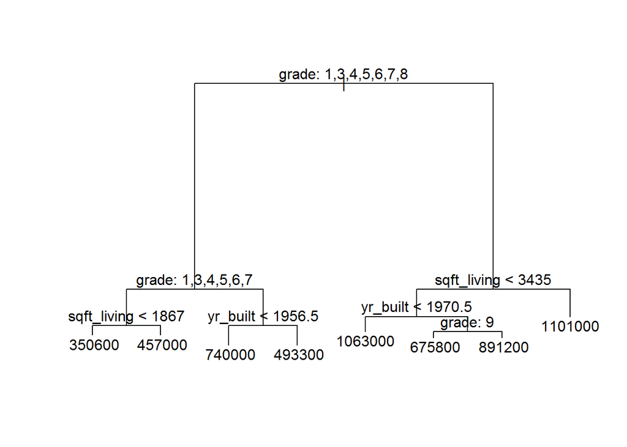

```r
plot(tree.fit)
text(tree.fit, pretty=0)
```

```r
tree.pred = predict(tree.fit, test)
sqrt(mean((test$price - tree.pred)^2))
```

```
## [1] 191385.4
```

Nous allons à présent essayer de réduire la profondeur de l’arbre en utilisant la méthode de *cross validation* pour déterminer une profondeur optimale.

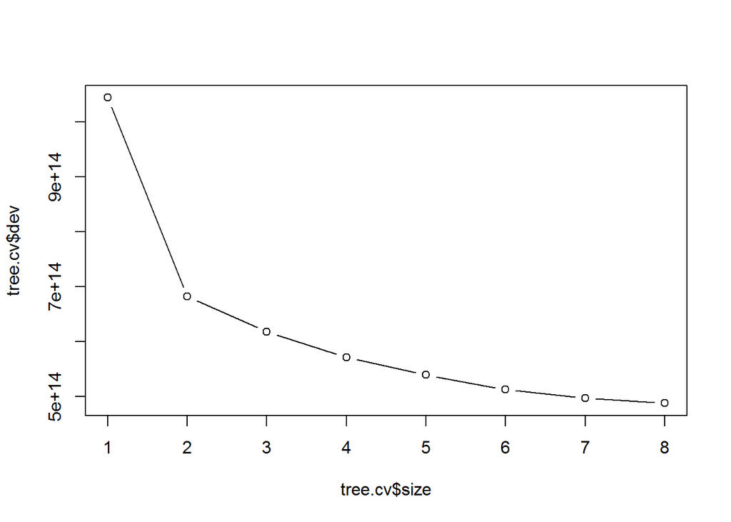

```r
tree.cv = cv.tree(tree.fit)
plot(tree.cv$size, tree.cv$dev, type="b")
```

```r
tree.min = which.min(tree.cv$size)
tree.min
```

```
## [1] 8
```

La profondeur obtimale obtenue ci dessus correspond à la profondeur initial de notre arbre. Le RMSE est élevée, comparé aux scores des autres méthodes, sans doute parce que nous utilisons un seul arbre pour prédire le prix.  
Une technique appelée Random Forest permet d’amélioré la qualité des arbres de régression, en récupérant le résultat de plusieurs arbres de régression, construit différemment. Chaque split dans chaque arbre est calculé à partir d’un nombre de prédicateurs m < (nombre de prédicateurs totaux). Voici les résultats pour m = 5.

```r
rf.fit = randomForest(price~., data=train, mtry=5, ntree=50, importance=TRUE)
rf.pred = predict(rf.fit, test)
sqrt(mean((test$price - rf.pred)^2))
```

```
## [1] 162870
```

Le RMSE est bien meilleur que pour un seul arbre, ce qui semble logique. Cette méthode obtient le meilleur score sur le RMSE test.

## Conclusion

#### Analyse

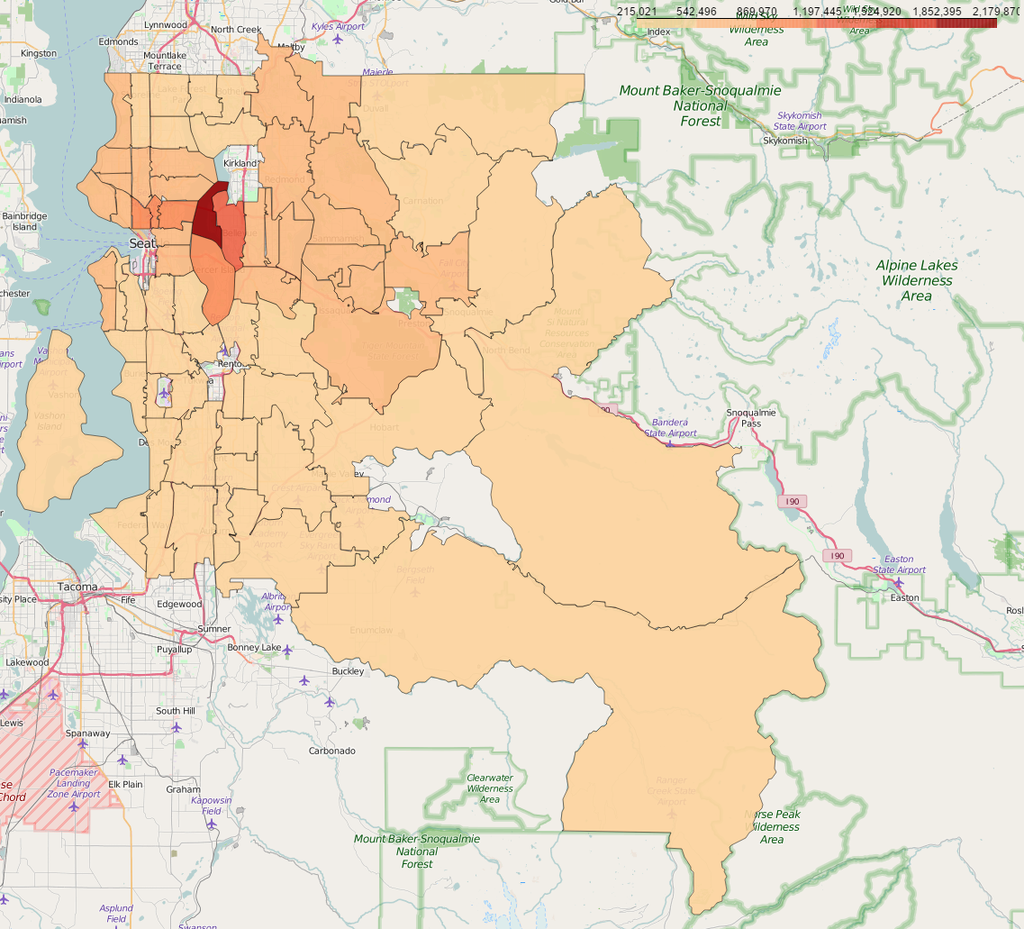

, il semblerait y avoir une forte relation entre le prix de la maison, et la région

#### Comparaison avec un autre kernel de Kaggle

Kaggle est une plateforme qui permet de partager des bases de données, ainsi que des scripts d’analyse pour ces base de données. En comparant mes résultats avec ceux obtenues par le script le mieux classé pour cette base de donnée (https://www.kaggle.com/harlfoxem/d/harlfoxem/housesalesprediction/house-price-prediction-part-2), j’obtiens de meilleur résultat sur le RMSE test.